# Reproducible Programming in R

# Reproducible Programming

## What do you want to do?

> - Access data
> - Build models
> - Test hypotheses
> - Run analyses
> - Report the results
> - Share the results and the techniques with others

# What’s different about R?

## What’s different about R?

- Formulae and factors
- Data frames
- Subsetting data
- Plotting data and generating reports and saving them to disk
- Massive database of user-supplied packages
- Specialised Integrated Development Environment (IDE)
  - RStudio
- Trivial to create your own packages
  - Integration with GitHub

## What are formulae?

- Formulae!
- Compact symbolic form for storing formulae for model building

```r
?formula
```

## What are factors?

- Vectors
  - but for data in a fixed number of categories, possibly ordered
- Compact form for storing categorical data for model building

```r
?factor
?ordered
?levels
```

## What are data frames?

- Tables (as from a spreadsheet)
  - One or more rows of data
  - Named columns of fixed type
- Fundamental data structure for most modelling functions

```r
head(mtcars)
```

```
##                    mpg cyl disp  hp drat    wt  qsec vs am gear carb
## Mazda RX4         21.0   6  160 110 3.90 2.620 16.46  0  1    4    4
## Mazda RX4 Wag     21.0   6  160 110 3.90 2.875 17.02  0  1    4    4
## Datsun 710        22.8   4  108  93 3.85 2.320 18.61  1  1    4    1
## Hornet 4 Drive    21.4   6  258 110 3.08 3.215 19.44  1  0    3    1
## Hornet Sportabout 18.7   8  360 175 3.15 3.440 17.02  0  0    3    2
## Valiant           18.1   6  225 105 2.76 3.460 20.22  1  0    3    1
```

```r
?data.frame
?read.csv
?read.table
```

## How do we subset vectors?

```r
vec <- c(1, 2, 3)
vec[vec > 2]
```

```
## [1] 3
```

```r
vec <- 1:3
vec > 2
```

```
## [1] FALSE FALSE  TRUE
```

```r
vec <- seq(from = 1, to = 3)
subs <- c(T, F, T)
vec[subs]
```

```
## [1] 1 3
```

## How do we subset data frames?

```r
df <- data.frame(val = c(1, 2, 3),
                 other = c("a", "b", "a"))
df$other
```

```
## [1] "a" "b" "a"
```

```r
df[df$other == "b", ]
```

```
##   val other
## 2   2     b
```

```r
subset(df, val == 1)
```

```
##   val other
## 1   1     a
```

## How do we subset data frames?

But these things are constantly evolving:

```r
library(dplyr)
df %>% filter(other == "b")
```

```
##   val other
## 1   2     b
```

```r
mtcars %>% filter(mpg > 20) %>% filter(carb >= 4)
```

```
##               mpg cyl disp  hp drat    wt  qsec vs am gear carb
## Mazda RX4      21   6  160 110  3.9 2.620 16.46  0  1    4    4
## Mazda RX4 Wag  21   6  160 110  3.9 2.875 17.02  0  1    4    4
```

## How do we plot?

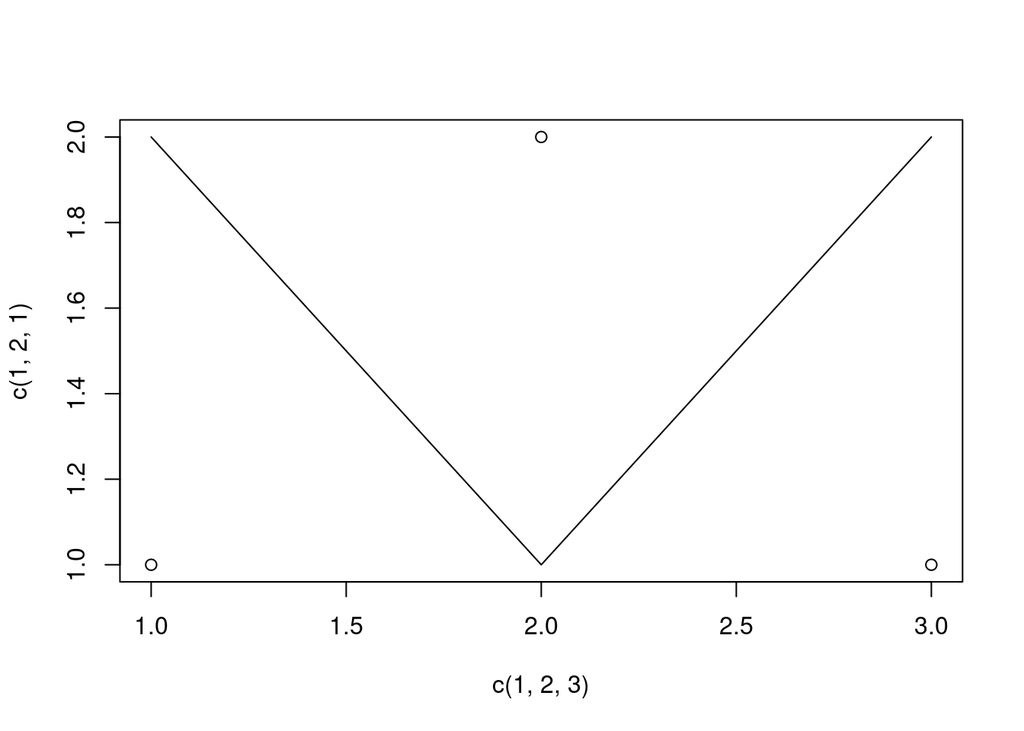

```r
plot(c(1, 2, 3), c(1, 2, 1))
lines(c(1, 2, 3), c(2, 1, 2))
```

## How do we plot?

Again, there are much more sophisticated ways, as you know… *e.g.*

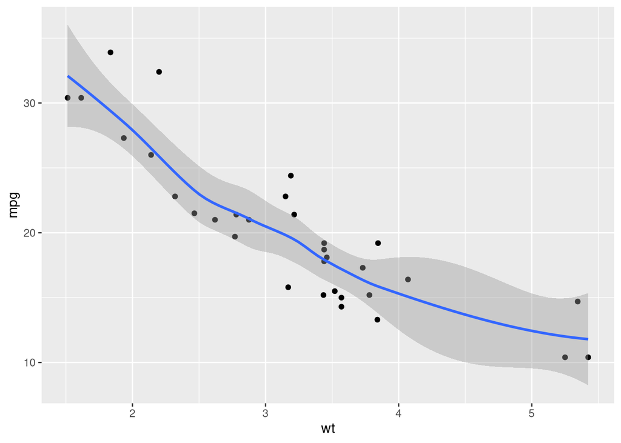

```r
library(ggplot2)
mtcars %>% ggplot(aes(wt, mpg)) + geom_point() + geom_smooth()
```

## How do we save to disk?

```r
png("out.png")
plot(c(1, 2, 3), c(1, 2, 1), type = "l")
dev.off()
```

```r
?pdf
?png
?Devices
```

## How do we save to disk?

Again, using ggplot2…

```r
g <- mtcars %>% ggplot(aes(wt, mpg)) + geom_point() + geom_smooth()
ggsave("out.png", g)
```

```r
?ggsave
```

## How do we use packages?

Install it first:

```r
install.packages(c("tibble"))
```

or from RStudio menus, and then use it:

```r
library(tibble)
```

not forgetting:

```r
update.packages()
```

occasionally.

## So how do you learn to program?

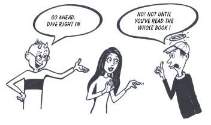

## What do you want to do?

- Access data
- Build models
- Test hypotheses
- Run analyses
- Report the results
- Share the results and the techniques with others

## What are you going to do?

Learn how to:

> - Write code
> - Write documentation
>   - So you can come back and understand it later
> - Identify and isolate reusable code
>   - So you don’t have to write it again later
> - Generate documented results
> - Read and understand other people’s code

## Remember…

[figure not shown]

“I honestly didn’t think you could even USE emoji in variable names. Or that there were so many different crying ones.”

https://imgs.xkcd.com/comics/code_quality.png

## What are you going to do?

> - Read and write well-documented and well-structured code
> - Use this to generate clear and well-documented results/reports

## How are you going to do it?

> - Problems will be structured around population dynamics, epidemiology and biodiversity
> - They will start off easy and ramp up
> - Packages (libraries) will allow you to solve many problems easily, but we are focusing on problems they don’t help with!

## Have fun!

[figure not shown]

http://phdcomics.com/comics/archive.php?comicid=946

## Starting with…

- Practical 1.1 - 1.6 (“practical1-x”) on population dynamics

and optionally:

- Practical A.1 - A.3 (“practicalA-x”) on if statements, functions and loops